# Analyzing animal movement patterns using potential functions - Preisler - 2013 - Ecosphere - Wiley Online Library

[Yale University](https://library.yale.edu/)

[Ecosphere](https://esajournals.onlinelibrary.wiley.com/journal/21508925)

[Volume 4, Issue 3](https://esajournals.onlinelibrary.wiley.com/toc/21508925/2013/4/3) art32 p. 1-13

[figure not shown]

Article

Open Access

# Analyzing animal movement patterns using potential functions

[Haiganoush K. Preisler](https://esajournals.onlinelibrary.wiley.com/authored-by/Preisler/Haiganoush+K.),

[Alan A. Ager](https://esajournals.onlinelibrary.wiley.com/authored-by/Ager/Alan+A.),

[Michael J. Wisdom](https://esajournals.onlinelibrary.wiley.com/authored-by/Wisdom/Michael+J.),

First published: 04 March 2013

https://doi.org/10.1890/ES12-00286.1

Citations: 37

[Yale Links](https://esajournals.onlinelibrary.wiley.com/servlet/linkout?suffix=s0&dbid=16384&doi=10.1890/ES12-00286.1&type=tocOpenUrl&url=http%3A%2F%2Fwa4py6yj8t.search.serialssolutions.com%2F%3F)

**Received:** 11 September 2012;revised 10 January 2013;11 January 2013;**published** 4 March 2013.

Corresponding Editor: R. Parmenter.

## Abstract

The advent of GPS technology has made it possible to study human-wildlife interactions on large landscapes and quantify behavioral responses to recreation and other anthropogenic disturbances at increasingly fine scales. Of particular interest are the potential impacts on habitat use patterns, energetics, and cascading impacts on fecundity and other life history traits for key wildlife species that are exposed to human activities. Statistical models quantifying effects of human activity on animal movement on a heterogeneous landscape are essential for understanding these potential impacts. Here we present a statistical framework for analyzing movement data that is based on the concept of a potential surface. The potential surface is motivated by the assumption that animals are moving on a space-time surface with regions or points of attraction or of repulsion. We demonstrate the use of the technique by analyzing movement data from a long-term controlled experiment to evaluate the responses of free ranging Rocky Mountain elk (*Cervus elaphus*) to anthropogenic disturbances that vary in time and space. Our results demonstrated a strong avoidance of elk to all-terrain vehicles detected up to one km from the disturbance. Elk avoidance of mountain bikers was detected up to 500 m, and avoidance of hikers and horseback riders was detected to 200 m.

## Introduction

Fine scale data-logging technology, such as global positioning systems (GPS), has stimulated many new approaches for analyzing and modeling movement patterns of free-ranging animals. Models of animal movements provide a quantitative framework to analyze spatiotemporal effects of anthropogenic disturbances, predators, and conspecifics. Of particular interest are the connections between movements and habitat use, energetics, and life history traits for keystone wildlife species that are increasingly exposed to human activities (Sawyer and Kaufman 2011).

Dynamics of free-ranging animal movements are complex, even without consideration of anthropogenic impacts. A wide range of models have been formulated and applied to animal movement. Most methods involve a Markov process such as uncorrelated or simply correlated random walk where the location of an animal at each step depends on the location in the previous step (Turchin 1998, Okubo and Levin 2001, Morales et al. 2004, Codling and Hill 2005, Smouse et al. 2010). Other processes include the Brownian Bridges models where the continuous movement paths are estimated assuming conditional random walk between successive locations (Horne et al. 2007, Sawyer et al. 2009). State-space or hidden Markov models assume locations of animals are a function of the unobserved state of the system (location or velocity) at a previous general time (Johnson et al. 2008, Dowd and Joy 2011). Other models have been explored for modeling movement using mechanistic models that incorporate effects of explanatory variables, such as human disturbances and landscape features (Forester et al. 2007, McClintock et al. 2012). The approaches listed above model the stochastic differential equations of motion (SDE), or the velocity of the motion, as a function of explanatory variables. Our present work is based on the idea of potential functions that are used to motivate specific functional forms for the SDEs. This framework may be used in conjunction with other methods, such as state-space models, by presenting a mechanism for arriving at an equation for the expected step sizes of movement. Potential functions are motivated by methods from physics where the motion of a physical particle is modeled as being affected by its location on a potential surface and by its relative distances from other particles, regions, or barriers (Hirsch et al. 2004, Taylor 2004). An attractive feature of the potential function approach is the ease with which multiple factors affecting motion (e.g., foraging behavior, topography, human disturbance) can be incorporated into a mechanistic model and then parameterized via a regression routine. The estimation methods assume a Markovian/diffusion process which is then generalized to more realistic stochastic processes by introducing, for example, serial correlations in the error term. Our goals in the current paper are to (1) provide ecologists an overview of the potential function modeling approach, (2) demonstrate its practical implementation with readily-available regression routines (e.g., open access R programing software), (3) extend the techniques presented in our previous work (Brillinger et al. 2004, Brillinger 2010, Brillinger et al. 2011) to accommodate serial correlations, and (4) use the technique to study movements from a long-term controlled experiment for evaluating responses of free ranging Rocky Mountain elk (*Cervus elaphus*) to multiple anthropogenic disturbances, including all-terrain vehicle (ATV) riding, hiking, mountain biking, and horseback riding (Wisdom et al. 2004, Naylor et al. 2009).

## The Potential Function Approach

Our approach is motivated by the assumption that particles are moving on a space-time surface containing regions or points of attraction and repulsion. This potential field is similar to a topographic surface under the influence of gravity where objects are attracted to low points or hollows and repelled from high points or hills. A simple example with a point of attraction at (0, 0) is provided by the potential *H*(*x, y*) = (*x*<sup>2</sup> + *y*<sup>2</sup>) where a particle at *(x, y)* moves directly to (0, 0) on the surface (Fig. 1a). Next, if some random noise or perturbation is added to the potential, for example by shaking the surface, then the particle will still drift toward the point with lowest potential but with the path not straight but wiggling with an amplitude dependent on the level of the noise (see Fig. 1b, c). A second elementary example is provided by a process where a particle moves on a flat potential surface by means of statistically independent random steps, i.e., a random walk process with no drift.

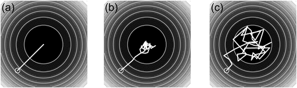

**Figure 1**

Open in figure viewer[PowerPoint](https://esajournals.onlinelibrary.wiley.com/action/downloadFigures?id=i2150-8925-4-3-art32-f01&partId=&doi=10.1890%2FES12-00286.1)

Tracks of a particle moving in a potential with a point of attraction (lowest point) at the center of the surface. Tracks in the three panels were generated by adding various amounts of random noise to the same potential. (a) No noise; (b) some random noise (small variance); (c) larger amount of random noise (larger variance). In each panel the starting point is indicated by the open circle.

An analytic foundation for this modeling framework is provided by a formal relationship between the potential surface and the velocity of the particle at a given location (*x, y*) and time *t*. In Newtonian physics, the velocity of a particle at location (*x, y*) is given by the negative of the gradient of the potential function at (*x, y*). The gradient of a surface is defined by the slopes in the *x*- and *y*-directions, that is grad *H* = (∂ *H*/∂x, ∂*H*/∂y). For example, for the potential surface in Fig. 1 with a point of attraction at (0, 0) the potential function *H*(*x, y*) = (*x*<sup>2</sup> + *y*<sup>2</sup>), and the velocity of the particle, as given by the speeds in the *x*- and *y*-directions are:

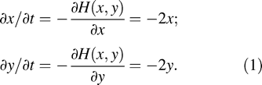

The minus signs in Eq. 1 are traditional. Eq. 1 provides one example of a gradient system (see Hirsch and Smale 1974:199–204). Other examples of parametric potential functions and the corresponding surfaces are provided in Fig. 2. The potential can be any differentiable function, including non-parametric smooth functions that are estimated from the data.

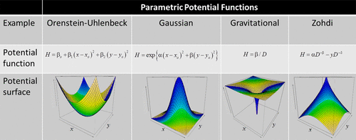

**Figure 2**

Open in figure viewer[PowerPoint](https://esajournals.onlinelibrary.wiley.com/action/downloadFigures?id=i2150-8925-4-3-art32-f02&partId=&doi=10.1890%2FES12-00286.1)

Four examples of parametric potential functions, with one point of attraction or repulsion at (*x*<sub>0</sub>, *y*<sub>0</sub>), and plots of the corresponding surfaces for specific values of the parameters (α, β, δ). . An example of the use of the Zohdi function is found in Zohdi (2003, 2009) and Brillinger et al. (2011).

Eq. 1 is important because while the potential itself may not be directly observable, the step sizes in the *x*- and *y*-directions, and thereby the approximate velocity of the animal, is observable. Consequently, if we assume the existence of a potential affecting the movements of an animal (up to random fluctuations) then it may be estimated, given observations on consecutive locations. This approach assumes that the potential function is differentiable. Complicated potential surfaces may be modeled and assessed using this framework. For example, there may be multiple regions of attraction where animals prefer to forage, versus regions of repulsion where human disturbances are frequent. A potential surface that integrates multiple factors affecting movement is developed by adding separate surfaces describing each of the attractions and repulsions together (Fig. 3 and Eq. 6). Potential functions may also be used to model animal movement as they are attracted to, or repulsed from, a moving entity (e.g., predator, hunter, vehicle). Brillinger et al. (2011) considered the case of modeling attraction between a given animal and conspecifics. When the point of attraction or repulsion is moving (e.g., person or conspecific) then the potential surface that defines the regions of attraction/repulsion are changing as well.

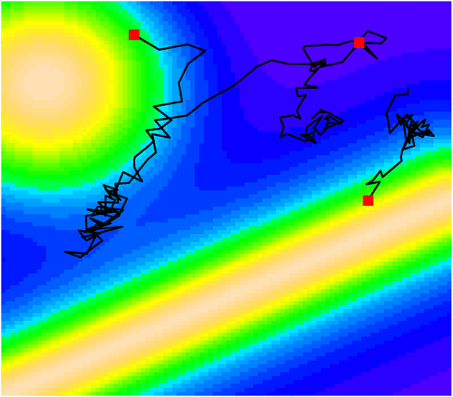

**Figure 3**

Open in figure viewer[PowerPoint](https://esajournals.onlinelibrary.wiley.com/action/downloadFigures?id=i2150-8925-4-3-art32-f03&partId=&doi=10.1890%2FES12-00286.1)

An example of a potential surface with two repulsion regions and simulated movement tracks within this surface. Red squares are the starting points of the tracks. The highest background values (pink then orange) indicate ridges (high potential), followed by yellow then green and finally blue then purple indicating valleys (low potential regions).

## Stochastic Differential Equations

Table 1. Examples of stochastic processes.

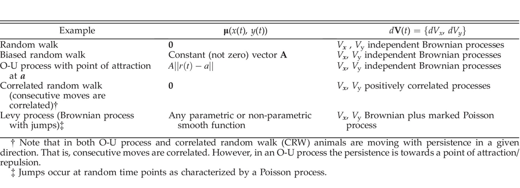

## Estimation Methods

There is substantial literature devoted to the topic of inference from stochastic differential equations (Sorensen 1997, Prakasa Rao 1999). Given a set of discrete observations on animal locations, the potential function and its gradients in continuous time (velocity) are used as a framework to build the discrete difference equation used in a regression model. Estimation is set in terms of the discrete approximation of the velocity in Eq. 2 as given by

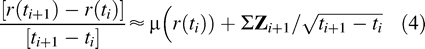

Given observed locations (*x<sub>i</sub>*, *y<sub>i</sub>*) for what may be unequally spaced times *t*<sub>1</sub> < *t*<sub>2</sub> < … < *t<sub>i</sub>* < … < *t<sub>m</sub>*, parameters, **Θ**, of a differentiable function, *H*(*x, y|*Θ), may be estimated by the regression model

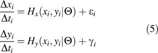

where; Δ*x<sub>i</sub>* = (*x<sub>i</sub>*<sub>+1</sub> − *x<sub>i</sub>*); Δ*y<sub>i</sub>* = (*y<sub>i</sub>*<sub>+1</sub> − *y<sub>i</sub>*); Δ*t<sub>i</sub>* = (*t<sub>i</sub>*<sub>+1</sub> − *t<sub>i</sub>*); *H<sub>x</sub>*, *H<sub>y</sub>* are the partial derivatives of *H*(*x, y|*Θ) with respect to *x* and *y* and where ε and γ are random noises. In the case where the error terms ε<sub>i</sub> and γ<sub>i</sub> are independent, ordinary least squares regression routines may be used to estimate the parameters. The error terms may not be independent if the step sizes, Δ*x<sub>i</sub>*, Δ*y<sub>i</sub>*, are correlated, cov(ε*<sub>i</sub>,* γ*<sub>i</sub>*) ≠ 0, or if the sample includes observations on more than one subject/animal resulting in within subject correlated errors. Observation error in our study was assumed to be negligible relative to the stochastic error, although this assumption needs to be carefully examined on a study by study basis (see *The Data* section). Finally, serial correlation may necessitate the use of an autoregressive model.

The gradient of the potential surface, when displayed as a vector field of arrows, provides an estimate of the average velocity of an animal at a point. Sometimes the average velocity of animals is of interest in itself. One may use a nonparametric smooth function of location to estimate the discrete velocities without relating them to a specific parametric potential surface. Estimation in this case can be carried out using the two-dimensional tensor spline functions (Wood 2006) or a two-dimensional locally weighted regression routine (Hastie and Tibshirani 1990).

## An Example on Elk Movement

### The experiment and the data

Here we demonstrate potential functions that describe the strength of repulsion between elk and four different human activities (riding an All-terrain vehicle (ATV), biking, hiking, and equestrian riding), using data from a controlled landscape experiment at the Starkey Experimental Forest and Range in eastern Oregon (Wisdom et al. 2004, Preisler et al. 2006, Naylor et al. 2009). In this experiment, 25 elk were followed (using Loran-C technology and GPS collars) during summer for four years (2002–2005). The purpose of the study was to understand responses of elk to four distinct recreational disturbances (henceforth treatments). During 2002–2004, each treatment was implemented for five days followed by a nine-day control period where all human activities were excluded. For each 5-d treatment period, two recreationists, moving independently, implemented one type of disturbance (ATV riding, mountain biking, hiking, or horseback riding). Each type of disturbance was implemented on 32 km of trails twice daily, once in the morning (approximately 08:00 to 12:00 local time) and once in the afternoon (approximately 1300 to 1700 local time) (Wisdom et al. 2004, Naylor et al. 2009). Each pair of recreationists was equipped with a GPS unit that tracked their locations on a continual basis (Wisdom et al. 2004). Data used in our analysis were limited to cases with elapsed time between consecutive observations less than 15 min. The median time between observations was 5 min with 85% less than 5.5 min. The mean error associated with the telemetry locations was <20 m for the GPS data (92% of the data used) and <50 m for the Loran-C data. Consequently, the assumption of negligible measurement error in the model was not unreasonable. For each elk observation, the distance to the disturbance associated with the step size between time *t* and *t* + Δ was calculated by using the nearest GPS location of the disturbance within 5 min of the observed elk location at time *t*. In 2005, treatments were excluded from the study area and elk location data were obtained to analyze movement patterns in the absence of human activities.

### Estimation

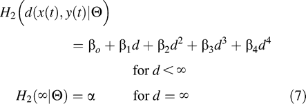

The regression equations used for estimation purposes were motivated by Eqs. 6 and 7. They are the discrete approximations (difference equations) of their partial derivatives with respect to *x* and *y*. For *d* < ∞, i.e., for days with human disturbance, the difference equations are given by

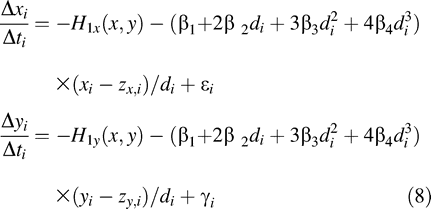

and for control days (*d* = ∞) are given by

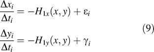

## Results

### Stochastic terms

Correlations between the step sizes in the *x*- and *y*-directions were negligible for both control days and treatment days with ρ(ε*<sub>i</sub>,* γ*<sub>i</sub>*) equal to 0.035 for control and −0.003 for treatment. Therefore, the matrix **Σ** in Eq. 2 was set to the diagonal matrix σ<sup>2</sup>**I**. The serial correlations ρ(ε*<sub>i</sub>,* ε*<sub>i</sub>*<sub>−1</sub>), ρ(γ*<sub>i</sub>,* γ*<sub>i</sub>*<sub>−1</sub>) ranged between 0.21 and 0.36 for the four time periods during control days and between 0.32 and 0.52 for the four disturbances during treatment days. The larger values tended to be for serial correlations in the *y*-direction. The estimated serial correlations are an indication that the underlying continuous process is not Markovian because there is some evidence that an elk's location at time *t* depends not only on its location at *t* − 1 (Markov process) but also on its location two periods ago.

### Diurnal movement patterns during control days

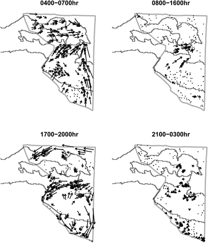

**Figure 4**

Open in figure viewer[PowerPoint](https://esajournals.onlinelibrary.wiley.com/action/downloadFigures?id=i2150-8925-4-3-art32-f04&partId=&doi=10.1890%2FES12-00286.1)

Estimated (smoothed) movement vectors for four periods of the day in the absence of human disturbances. Speed of movement is proportional to the length of the movement arrows. The two time intervals on the left are associated with periods of maximum crepuscular movements to and from foraging areas. The two time intervals on the right are associated with periods of rest and rumination.

### Movements with respect to disturbance

As noted above, treatments were introduced into the experimental region only during the day time hours 08:00–16:00. Undisturbed elk exhibited seemingly random movement and regions of attraction or repulsion were not apparent, contrary to the pattern seen during the early morning (04:00–07:00) or evening hours (Fig. 4). Accordingly, it seemed reasonable to use a model with the non-parametric term *H<sub>1</sub>*[*x*(*t*), *y*(*t*)] in Eq. 6 set to a constant, and consequently, its partial derivatives, *H*<sub>1*x*,</sub> *H*<sub>1*y*</sub>, in Eq. 8 are zero. The exact model fitted to the data on treatment days is shown in the R-code given in the Supplement. The estimated parameter values for {β<sub>1</sub>, ..., β<sub>4</sub>} were next used in Eq. 7 to produce Fig. 5 depicting the height of the potential surface as a function of the distance between elk and the four disturbances. The estimated curves in Fig. 5 seem to indicate that elk within a few hundred meters of any of the four disturbances were, on average, moving away (repelled) from the disturbance. The repulsion appeared to be strongest in terms of both magnitude and distance for the ATV treatment, with some repulsion observed up to 1.0 km. Repulsion from bikers was detected up to about 500 m, after which the function is not significantly different from a horizontal line. The smallest estimated repulsion effect was observed between elk and hikers and elk and horseback riders, with significant repulsion observed only up to about 200 m.

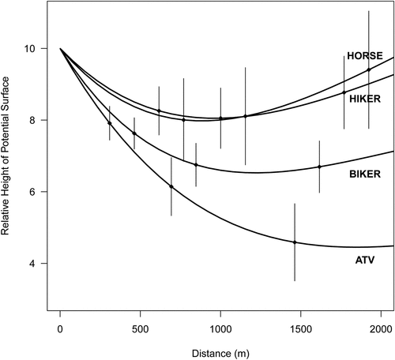

**Figure 5**

Open in figure viewer[PowerPoint](https://esajournals.onlinelibrary.wiley.com/action/downloadFigures?id=i2150-8925-4-3-art32-f05&partId=&doi=10.1890%2FES12-00286.1)

Estimated height of the potential surfaces as a function of the distance to each of the four disturbances, ATV riding (ATV), bike riding (BIK), hiking (HIK) and horseback riding (HRS). Vertical lines are ±2 SE bounds.

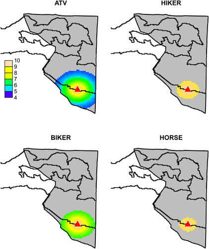

**Figure 6**

Open in figure viewer[PowerPoint](https://esajournals.onlinelibrary.wiley.com/action/downloadFigures?id=i2150-8925-4-3-art32-f06&partId=&doi=10.1890%2FES12-00286.1)

Estimated potential surfaces when the human disturbance was located at a particular point (red triangle) on the route within the study area. The grey areas indicate regions where the potential surface is approximately flat.

## Discussion

We have presented a framework for studying the movement of animals (in particular attraction and repulsion) that couples a conceptual model of behavior with statistical methods and estimation procedures. In this framework, motion of an animal is assumed to be affected by its location relative to surrounding biophysical factors, including conspecifics, predators, humans, or sources of food. We also provided example SDEs and accompanying R scripts (Supplemental Material) that can be modified to implement the framework as part of other movement studies concerned with detecting and quantifying landscape patterns of movements and their timing with respect to different behavioral states (e.g., foraging, migration, avoidance).

Our methods were initially developed to explain animal movement in terms of human and ecological disturbances, and the example we presented concerned quantifying the strength of repulsion of elk from four different human disturbances. This is in contrast to a number of other recent studies that characterized temporal changes in movement patterns associated with different behavioral states (Forester et al. 2007, Dowd and Joy 2011). Potential surfaces can be applied to studies used to model animal interactions with patch boundaries and core area by including locational variables like distance to patch edge or centroid. State changes can be then modeled as a bivariate function that includes both distance metrics and time as the explanatory variables. Time steps can be hour of day or season in year (or both) depending on the temporal scale of the data and the movement behavior in question. An example of fitting such a potential function is given in Preisler et al. (2004) where the effect of habitat features, such as refugia from roads, food patches, streams and canyons on movement were studied by time of day and season. In movement studies on marine mammals, for example, where sea surface temperature can be an important explanatory variable (e.g., Jonsen et al. 2003), a univariate function of the changing temperature, *H*(*T*(*t*)), can be used as a potential function, with points of attraction (valleys in the potential surface) being regions with higher temperatures. One may use a polynomial function with temperature, *T*, as an explanatory variable. Note that in this example temperature is a function of time, thus it is possible to represent time in the model (i.e., a potential function varying in time) without having to include it explicitly in the equation. In Brillinger et al. (2008) the authors study the movement of Hawaiian monk seals (*Monachus schauinslandi*) using a time varying potential function with two points of attraction to describe the migration of the seal as it moves between a foraging region in the sea and resting areas on land.

The complexity of the stochastic component of a movement model is determined by the data at hand. In our elk example, serial correlation was detected beyond that of a Markov process and an autoregressive model was employed. A Lévy process (diffusion process with jumps) can be useful for studying reactions of animals to outside stimuli (e.g., cars, or other animals). However, it was not used in the present study because locations and times of the disturbances were known. More complicated error structures, such as when measurement errors are too large to ignore, may necessitate the use of a linear or non-linear state-space model. However, one may still base the form of the difference equation on a function derived from a hypothesized potential function.

Brownian-bridges are another technique that has been used to analyze movements. In particular, when the animal's location is known at a sequence of locations, one can estimate positions in between using Brownian bridges (Horne et al. 2007), and then estimate the utilization distribution as a function of location-specific habitat variables. Eq. 3 of our model shows the relationship between the utilization distribution and a potential function independent of time. Thus Brownian-bridges models may be linked to a particular form of a potential function.

Elapsed time between consecutive observations was small (∼5 min) in the present study. However, the utility of potential function models is not limited to high frequency data; the approach can be applied to whatever spatiotemporal scale is of interest. In the present study short-term responses to human disturbances were of interest, whereas in the Hawaiian monk seal example (Brillinger et al. 2008) the data were daily observations. In an example on the transition of Sierra Nevada yellow-legged frogs (*Rana sierrae*) to breeding, feeding and overwintering locations the time steps were months (Matthews and Preisler 2010). One can also interpolate between consecutively observed locations to increase the temporal resolution of location data using Brownian bridges (Horne et al. 2007) or simple linear or spline interpolation (Brillinger et al. 2011).

Deriving ecological inferences from animal movement data has been difficult, in part because it is a multistate, stochastic process (McClintock et al. 2012). Elk, like many ungulates, exhibit pronounced switching behavior between fine- and broad-scale movements, corresponding to crepuscular transitions in habitat preferences (Ager et al. 2003). Different landscape features and associated scales of perception may be responsible for decision making and navigation during these phases. State-space models are one approach to handle multiphasic movements where both time-dependent and time-independent factors must be considered (Forester et al. 2007). More recently, nested, discrete, multi-state movement models have been proposed as a simplified framework to facilitate the analyses of the growing body of movement data (McClintock et al. 2012). We submit that SDEs derived from potential functions enhance the above approaches by connecting a physical model to the discrete difference equations that may then be readily estimated with existing statistical packages.

## Acknowledgments

We thank Professor David Brillinger for his comments and help during the preparation of this manuscript. We thank Jennifer Hafer and Bridgett Naylor for data preparation and management. We are also thankful to two referees and the associate editor for their valuable comments on the manuscript. Special thanks go to Michelle Day for her help with Fig. 2 and other copy editing issues. This research was supported with funding from the Oregon Department of Parks and Recreation and the USDA Forest Service Pacific Northwest and Pacific Southwest Research Stations.

## Supplemental Material

**Supplement**

## Citing Literature

[Volume4, Issue3](https://esajournals.onlinelibrary.wiley.com/toc/21508925/2013/4/3)

March 2013

Pages 1-13

### Recommended

[Download PDF](https://esajournals.onlinelibrary.wiley.com/doi/pdf/10.1890/ES12-00286.1)

back